# Milestone 2: Analysis of Rental Housing Market Trends in New Zealand/Aotearoa

Shuo Mao 437681258

2024-03-14

### Goal

The objective of this project is to analysis the trends in rental housing market in New Zealand/Aotearoa over the pass 30 years, focusing on rental cost changes and housing afforability. ### Data Source The data for this analysis is primarily privode from Tenancy Services[https://www.tenancy.govt.nz/about-tenancy-services/data-and-statistics/rental-bond-data/] by public database to provide a comprehensive overview of the market trends.

```r
# Load the data
rental.df <- read_csv("/Users/vicmon/Downloads/detailed-monthly-february-2024-tla-tenancy.csv", show_col_types = FALSE)
#summary of rental.df
summary(rental.df)
```

```
##    Time Frame          Location Id       Location          Lodged Bonds
##  Min.   :1993-02-01   Min.   :-99.00   Length:24914       Min.   :    6.0
##  1st Qu.:2001-02-01   1st Qu.: 23.00   Class :character   1st Qu.:   24.0
##  Median :2008-10-01   Median : 40.00   Mode  :character   Median :   66.0
##  Mean   :2008-09-21   Mean   : 38.54                      Mean   :  394.8
##  3rd Qu.:2016-06-01   3rd Qu.: 57.00                      3rd Qu.:  147.0
##  Max.   :2024-02-01   Max.   : 76.00                      Max.   :18111.0
##   Active Bonds     Closed Bonds      Median Rent    Geometric Mean Rent
##  Min.   :    33   Min.   :    0.0   Min.   : 38.0   Min.   : 43.0
##  1st Qu.:   468   1st Qu.:   21.0   1st Qu.:153.0   1st Qu.:151.0
##  Median :  1314   Median :   63.0   Median :220.0   Median :213.0
##  Mean   :  8054   Mean   :  368.8   Mean   :248.2   Mean   :239.7
##  3rd Qu.:  2961   3rd Qu.:  138.0   3rd Qu.:310.0   3rd Qu.:301.0
##  Max.   :412560   Max.   :17145.0   Max.   :750.0   Max.   :708.0
##  Upper Quartile Rent Lower Quartile Rent Log Std Dev Weekly Rent
##  Min.   : 63.0       Min.   : 29.0       Min.   :0.0300
##  1st Qu.:179.0       1st Qu.:130.0       1st Qu.:0.2400
##  Median :251.0       Median :180.0       Median :0.2900
##  Mean   :288.9       Mean   :206.3       Mean   :0.2939
##  3rd Qu.:365.0       3rd Qu.:253.0       3rd Qu.:0.3400
##  Max.   :950.0       Max.   :620.0       Max.   :1.1200
```

### Data Processing

At this stage, we only interest with rental price trend in different regions over time and the relation between bonds and rental price, hence we can remove some of unrelated attributes. In addition, we will using median value to replace any missing value in the median_rent column to handling missing valuables.

```
## [1] 5
```

```
##    location          median_rent     active_bonds      time_frame
##  Length:24914       Min.   : 38.0   Min.   :    33   Min.   :1993-02-01
##  Class :character   1st Qu.:153.0   1st Qu.:   468   1st Qu.:2001-02-01
##  Mode  :character   Median :220.0   Median :  1314   Median :2008-10-01
##                     Mean   :248.2   Mean   :  8054   Mean   :2008-09-21
##                     3rd Qu.:310.0   3rd Qu.:  2961   3rd Qu.:2016-06-01
##                     Max.   :750.0   Max.   :412560   Max.   :2024-02-01
##   closed_bonds
##  Min.   :    0.0
##  1st Qu.:   21.0
##  Median :   63.0
##  Mean   :  368.8
##  3rd Qu.:  138.0
##  Max.   :17145.0
```

### Data exploration

##### Trend analysis of rental prices in AUCKLAND region

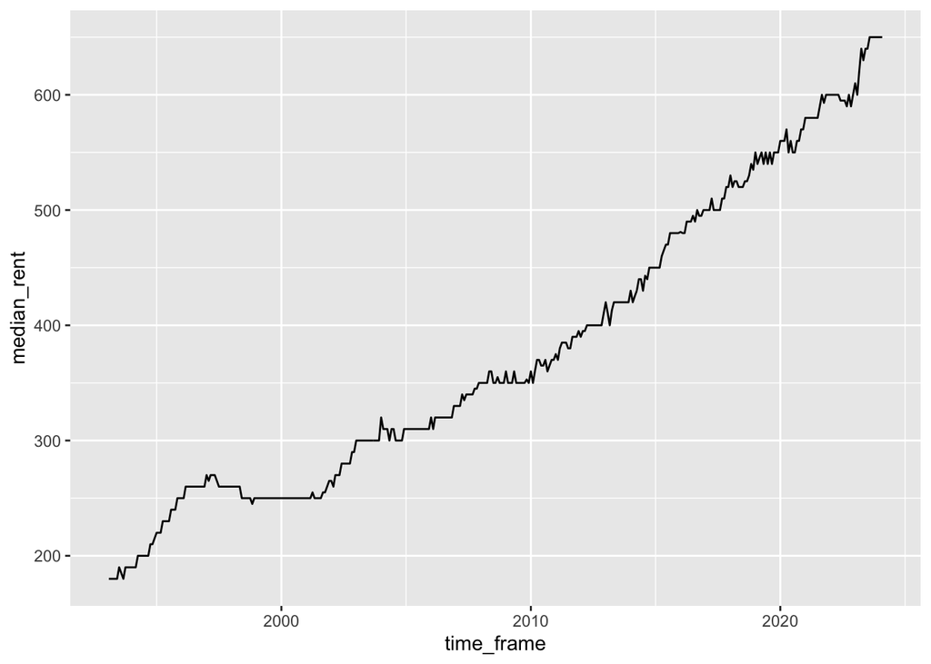

The graph above depicts the trends in Auckland’s rental market over the last thirty years. It indicates a gradual increase in rental costs over decades, with a noticeable acceleration beginning in 2010. This increase of price rise reflects substantial market shifts in recent years.

##### rental price variability of AUCKLAND region

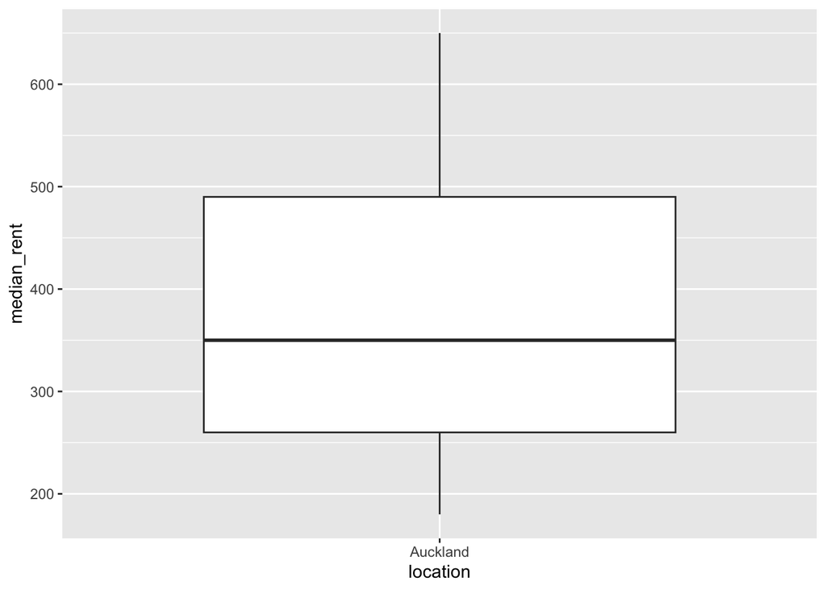

##### relation between BOND type and rental market of AUCKLAND region

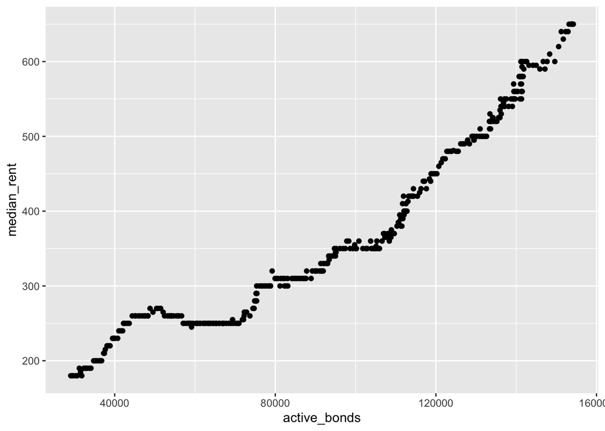

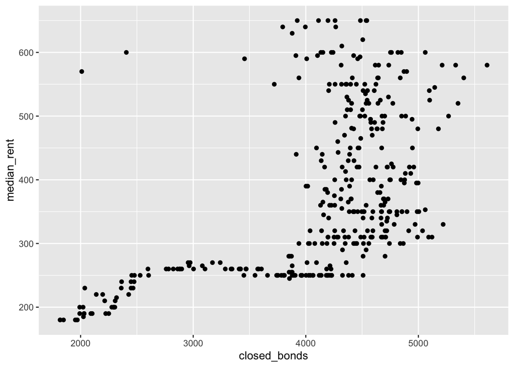

The two charts above show a higher association between rental prices and active bonds than with closed bonds. This suggests that active bonds, which represent ongoing tenancies, are more representative of current market circumstances and have a bigger impact on rental pricing dynamics.

##### Analytical plan

The goal of this project is too analysis the trend in the rental housing market in New Zealand in past 30 years, with a particular focus on changes in rental costs and housing affordability.

The primary analysis proposed are:

- Time series analysis: This approach is appropriate for the data because to its temporal nature. By examining rental prices as a time series, we may find seasonal patterns, long-term trends, and possibly cyclical fluctuations. Models such as ARIMA can assist estimate future rental price changes based on previous data.
- Regression analysis: To determine the influence of various factors on rental pricing, regression models will be used. This method will allow us to measure the impact of factors like the number of active and closed bonds, district-specific economic conditions, and other important variables on median rental pricing.
- Geospatial analysis: Given the geographic heterogeneity in rental pricing, geospatial analysis will be employed to illustrate and analyse regional price patterns. This strategy will assist identify locations with quick price spikes or declines, as well as analyzing regional inequalities in housing affordability

Additional attributes for modeling can be consider as ‘Housing quality’, ‘general Economics’, and ’Government policy impact.

# appendix

## Rental price trend over North Island

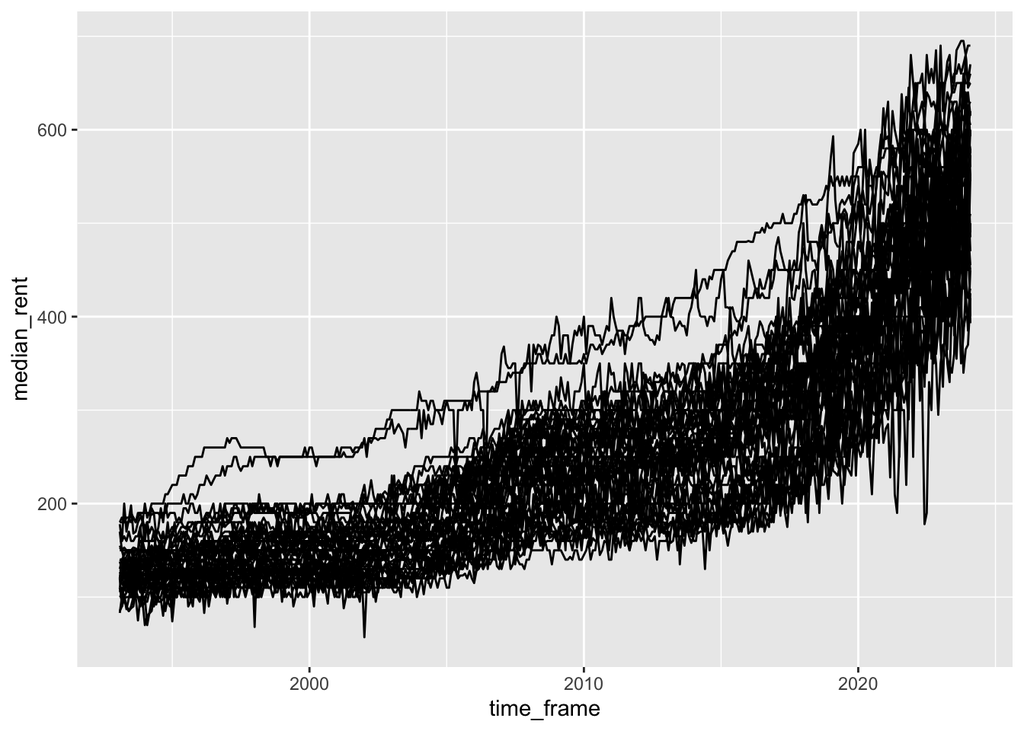

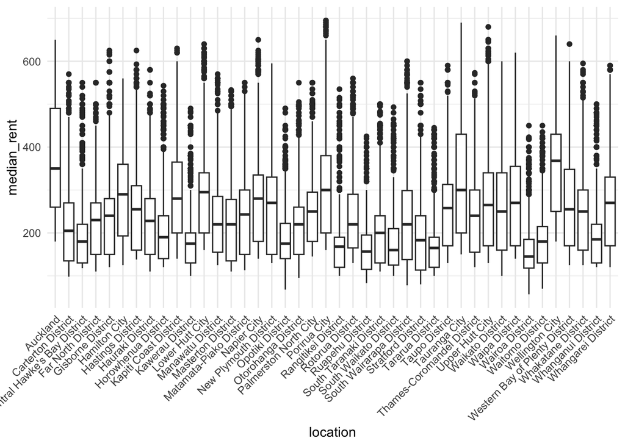

## Rental price trend over South Island

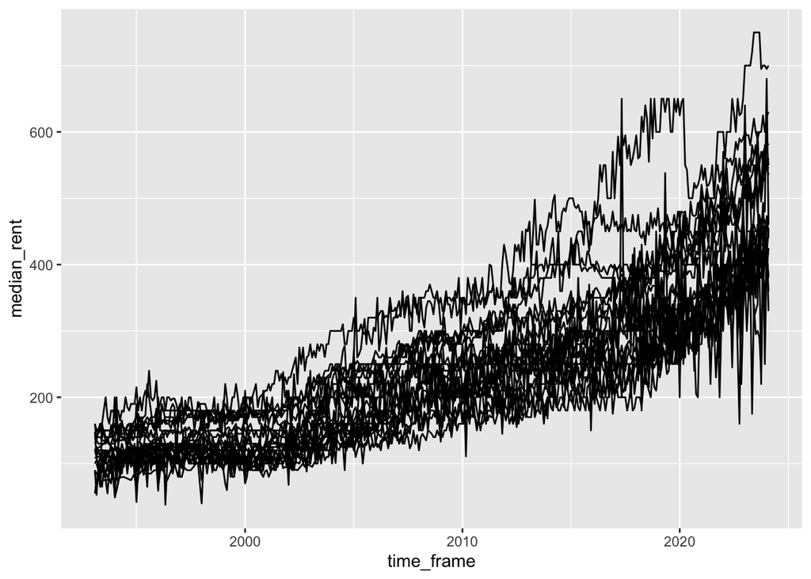

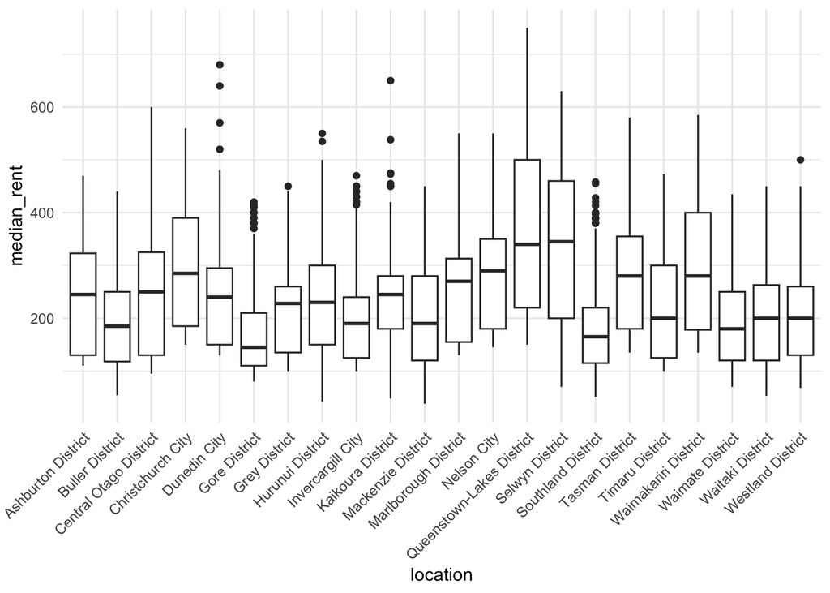